# Risk Factor Analysis

## Outcome Variable

**Outcome Variable:** ever_swasted

## Predictor Variables

**Intervention Variable:** enstunt

**Adjustment Set:**

- arm
- sex
- W_mage
- meducyrs
- feducyrs
- vagbrth
- single
- brthmon
- W_parity
- delta_W_mage
- delta_meducyrs
- delta_feducyrs
- delta_vagbrth
- delta_single
- delta_brthmon
- delta_W_parity

## Stratifying Variables

The analysis was stratified on these variable(s):

- agecat
- studyid
- country

## Data Summary

| agecat | studyid | country | enstunt | ever_swasted | n_cell | n |
| --- | --- | --- | --- | --- | --- | --- |
| 0-24 months (no birth wast) | CMC-V-BCS-2002 | INDIA | 0 | 0 | 249 | 368 |
| 0-24 months (no birth wast) | CMC-V-BCS-2002 | INDIA | 0 | 1 | 44 | 368 |
| 0-24 months (no birth wast) | CMC-V-BCS-2002 | INDIA | 1 | 0 | 64 | 368 |
| 0-24 months (no birth wast) | CMC-V-BCS-2002 | INDIA | 1 | 1 | 11 | 368 |
| 0-24 months (no birth wast) | CMIN | BANGLADESH | 0 | 0 | 149 | 268 |
| 0-24 months (no birth wast) | CMIN | BANGLADESH | 0 | 1 | 17 | 268 |
| 0-24 months (no birth wast) | CMIN | BANGLADESH | 1 | 0 | 82 | 268 |
| 0-24 months (no birth wast) | CMIN | BANGLADESH | 1 | 1 | 20 | 268 |
| 0-24 months (no birth wast) | COHORTS | GUATEMALA | 0 | 0 | 1003 | 1332 |
| 0-24 months (no birth wast) | COHORTS | GUATEMALA | 0 | 1 | 10 | 1332 |
| 0-24 months (no birth wast) | COHORTS | GUATEMALA | 1 | 0 | 302 | 1332 |
| 0-24 months (no birth wast) | COHORTS | GUATEMALA | 1 | 1 | 17 | 1332 |
| 0-24 months (no birth wast) | COHORTS | INDIA | 0 | 0 | 6014 | 7135 |
| 0-24 months (no birth wast) | COHORTS | INDIA | 0 | 1 | 274 | 7135 |
| 0-24 months (no birth wast) | COHORTS | INDIA | 1 | 0 | 784 | 7135 |
| 0-24 months (no birth wast) | COHORTS | INDIA | 1 | 1 | 63 | 7135 |
| 0-24 months (no birth wast) | COHORTS | PHILIPPINES | 0 | 0 | 2617 | 3019 |
| 0-24 months (no birth wast) | COHORTS | PHILIPPINES | 0 | 1 | 228 | 3019 |
| 0-24 months (no birth wast) | COHORTS | PHILIPPINES | 1 | 0 | 153 | 3019 |
| 0-24 months (no birth wast) | COHORTS | PHILIPPINES | 1 | 1 | 21 | 3019 |
| 0-24 months (no birth wast) | CONTENT | PERU | 0 | 0 | 194 | 215 |
| 0-24 months (no birth wast) | CONTENT | PERU | 0 | 1 | 1 | 215 |
| 0-24 months (no birth wast) | CONTENT | PERU | 1 | 0 | 20 | 215 |
| 0-24 months (no birth wast) | CONTENT | PERU | 1 | 1 | 0 | 215 |
| 0-24 months (no birth wast) | EE | PAKISTAN | 0 | 0 | 183 | 377 |
| 0-24 months (no birth wast) | EE | PAKISTAN | 0 | 1 | 28 | 377 |
| 0-24 months (no birth wast) | EE | PAKISTAN | 1 | 0 | 128 | 377 |
| 0-24 months (no birth wast) | EE | PAKISTAN | 1 | 1 | 38 | 377 |
| 0-24 months (no birth wast) | GMS-Nepal | NEPAL | 0 | 0 | 441 | 660 |
| 0-24 months (no birth wast) | GMS-Nepal | NEPAL | 0 | 1 | 112 | 660 |

[output cut: 94 more lines]

The following strata were considered:

- agecat: 0-24 months (no birth wast), studyid: CMC-V-BCS-2002, country: INDIA
- agecat: 0-24 months (no birth wast), studyid: CMIN, country: BANGLADESH
- agecat: 0-24 months (no birth wast), studyid: COHORTS, country: GUATEMALA
- agecat: 0-24 months (no birth wast), studyid: COHORTS, country: INDIA
- agecat: 0-24 months (no birth wast), studyid: COHORTS, country: PHILIPPINES
- agecat: 0-24 months (no birth wast), studyid: CONTENT, country: PERU
- agecat: 0-24 months (no birth wast), studyid: EE, country: PAKISTAN
- agecat: 0-24 months (no birth wast), studyid: GMS-Nepal, country: NEPAL
- agecat: 0-24 months (no birth wast), studyid: Guatemala BSC, country: GUATEMALA
- agecat: 0-24 months (no birth wast), studyid: iLiNS-Zinc, country: BURKINA FASO
- agecat: 0-24 months (no birth wast), studyid: IRC, country: INDIA
- agecat: 0-24 months (no birth wast), studyid: JiVitA-3, country: BANGLADESH
- agecat: 0-24 months (no birth wast), studyid: JiVitA-4, country: BANGLADESH
- agecat: 0-24 months (no birth wast), studyid: Keneba, country: GAMBIA
- agecat: 0-24 months (no birth wast), studyid: LCNI-5, country: MALAWI
- agecat: 0-24 months (no birth wast), studyid: MAL-ED, country: BANGLADESH
- agecat: 0-24 months (no birth wast), studyid: MAL-ED, country: BRAZIL
- agecat: 0-24 months (no birth wast), studyid: MAL-ED, country: INDIA
- agecat: 0-24 months (no birth wast), studyid: MAL-ED, country: NEPAL
- agecat: 0-24 months (no birth wast), studyid: MAL-ED, country: PERU
- agecat: 0-24 months (no birth wast), studyid: MAL-ED, country: SOUTH AFRICA
- agecat: 0-24 months (no birth wast), studyid: MAL-ED, country: TANZANIA, UNITED REPUBLIC OF
- agecat: 0-24 months (no birth wast), studyid: NIH-Birth, country: BANGLADESH
- agecat: 0-24 months (no birth wast), studyid: NIH-Crypto, country: BANGLADESH
- agecat: 0-24 months (no birth wast), studyid: PROBIT, country: BELARUS
- agecat: 0-24 months (no birth wast), studyid: PROVIDE, country: BANGLADESH
- agecat: 0-24 months (no birth wast), studyid: ResPak, country: PAKISTAN
- agecat: 0-24 months (no birth wast), studyid: SAS-CompFeed, country: INDIA
- agecat: 0-24 months (no birth wast), studyid: SAS-FoodSuppl, country: INDIA
- agecat: 0-24 months (no birth wast), studyid: TanzaniaChild2, country: TANZANIA, UNITED REPUBLIC OF
- agecat: 0-24 months (no birth wast), studyid: ZVITAMBO, country: ZIMBABWE

### Dropped Strata

Some strata were dropped due to rare outcomes:

- agecat: 0-24 months (no birth wast), studyid: CONTENT, country: PERU
- agecat: 0-24 months (no birth wast), studyid: Guatemala BSC, country: GUATEMALA
- agecat: 0-24 months (no birth wast), studyid: LCNI-5, country: MALAWI
- agecat: 0-24 months (no birth wast), studyid: MAL-ED, country: BANGLADESH
- agecat: 0-24 months (no birth wast), studyid: MAL-ED, country: BRAZIL
- agecat: 0-24 months (no birth wast), studyid: MAL-ED, country: INDIA
- agecat: 0-24 months (no birth wast), studyid: MAL-ED, country: NEPAL
- agecat: 0-24 months (no birth wast), studyid: MAL-ED, country: PERU
- agecat: 0-24 months (no birth wast), studyid: MAL-ED, country: SOUTH AFRICA
- agecat: 0-24 months (no birth wast), studyid: MAL-ED, country: TANZANIA, UNITED REPUBLIC OF
- agecat: 0-24 months (no birth wast), studyid: PROBIT, country: BELARUS
- agecat: 0-24 months (no birth wast), studyid: PROVIDE, country: BANGLADESH

## Methods Detail

We're interested in the causal parameters $E[Y_a]$ for all values of $a \in \mathcal{A}$. These parameters represent the mean outcome if, possibly contrary to fact, we intervened to set all units to have $A=a$. Under the randomization and positivity assumptions, these are identified by the statistical parameters $\psi_a=E_W[E_{Y|A,W}(Y|A=a,W)]$. In addition, we're interested in the mean of $Y$, $E[Y]$ under no intervention (the observed mean). We will estimate these parameters by using SuperLearner to fit the relevant likelihood factors -- $E_{Y|A,W}(Y|A=a,W)$ and $p(A=a|W)$, and then updating our likelihood fit using a joint TMLE.

For unadjusted analyses ($W=\{\}$), initial likelihoods were estimated using Lrnr_glm to estimate the simple $E(Y|A)$ and Lrnr_mean to estimate $p(A)$. For adjusted analyses, a small library containing Lrnr_glmnet, Lrnr_xgboost, and Lrnr_mean was used.

Having estimated these parameters, we will then use the delta method to estimate relative risks and attributable risks relative to a prespecified baseline level of $A$.

# Results Detail

## Results Plots

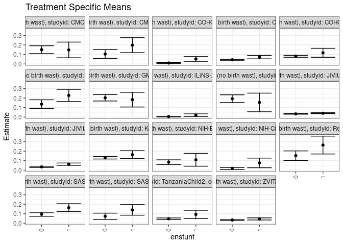

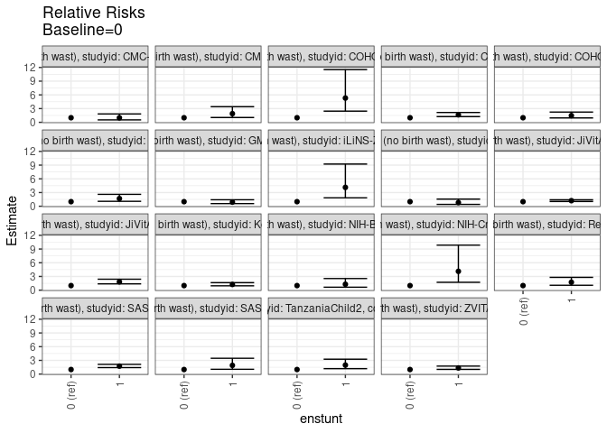

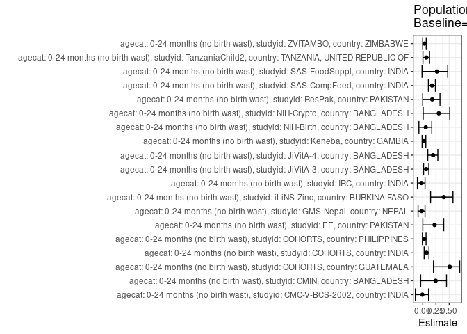

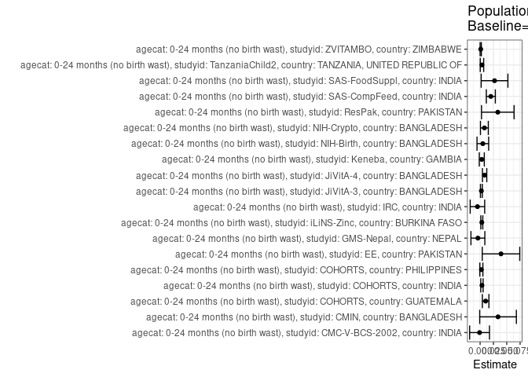

## Results Table

### Parameter: TSM

| agecat | studyid | country | intervention_level | baseline_level | estimate | ci_lower | ci_upper |
| --- | --- | --- | --- | --- | --- | --- | --- |
| 0-24 months (no birth wast) | CMC-V-BCS-2002 | INDIA | 0 | NA | 0.1505060 | 0.1092895 | 0.1917225 |
| 0-24 months (no birth wast) | CMC-V-BCS-2002 | INDIA | 1 | NA | 0.1477447 | 0.0652946 | 0.2301949 |
| 0-24 months (no birth wast) | CMIN | BANGLADESH | 0 | NA | 0.1044312 | 0.0583115 | 0.1505509 |
| 0-24 months (no birth wast) | CMIN | BANGLADESH | 1 | NA | 0.1977311 | 0.1188635 | 0.2765987 |
| 0-24 months (no birth wast) | COHORTS | GUATEMALA | 0 | NA | 0.0099282 | 0.0038125 | 0.0160439 |
| 0-24 months (no birth wast) | COHORTS | GUATEMALA | 1 | NA | 0.0527172 | 0.0278530 | 0.0775813 |
| 0-24 months (no birth wast) | COHORTS | INDIA | 0 | NA | 0.0437718 | 0.0387256 | 0.0488180 |
| 0-24 months (no birth wast) | COHORTS | INDIA | 1 | NA | 0.0716296 | 0.0540397 | 0.0892194 |
| 0-24 months (no birth wast) | COHORTS | PHILIPPINES | 0 | NA | 0.0801343 | 0.0701517 | 0.0901169 |
| 0-24 months (no birth wast) | COHORTS | PHILIPPINES | 1 | NA | 0.1174620 | 0.0699889 | 0.1649352 |
| 0-24 months (no birth wast) | EE | PAKISTAN | 0 | NA | 0.1358779 | 0.0899320 | 0.1818238 |
| 0-24 months (no birth wast) | EE | PAKISTAN | 1 | NA | 0.2278180 | 0.1636465 | 0.2919894 |
| 0-24 months (no birth wast) | GMS-Nepal | NEPAL | 0 | NA | 0.2026534 | 0.1690817 | 0.2362252 |
| 0-24 months (no birth wast) | GMS-Nepal | NEPAL | 1 | NA | 0.1832775 | 0.1060097 | 0.2605453 |
| 0-24 months (no birth wast) | iLiNS-Zinc | BURKINA FASO | 0 | NA | 0.0048852 | 0.0014475 | 0.0083229 |
| 0-24 months (no birth wast) | iLiNS-Zinc | BURKINA FASO | 1 | NA | 0.0201543 | 0.0068110 | 0.0334975 |
| 0-24 months (no birth wast) | IRC | INDIA | 0 | NA | 0.1932773 | 0.1522665 | 0.2342881 |
| 0-24 months (no birth wast) | IRC | INDIA | 1 | NA | 0.1538462 | 0.0556610 | 0.2520313 |
| 0-24 months (no birth wast) | JiVitA-3 | BANGLADESH | 0 | NA | 0.0333594 | 0.0303496 | 0.0363692 |
| 0-24 months (no birth wast) | JiVitA-3 | BANGLADESH | 1 | NA | 0.0405614 | 0.0355744 | 0.0455483 |
| 0-24 months (no birth wast) | JiVitA-4 | BANGLADESH | 0 | NA | 0.0345810 | 0.0280019 | 0.0411601 |
| 0-24 months (no birth wast) | JiVitA-4 | BANGLADESH | 1 | NA | 0.0630344 | 0.0508700 | 0.0751988 |
| 0-24 months (no birth wast) | Keneba | GAMBIA | 0 | NA | 0.1304132 | 0.1173287 | 0.1434977 |
| 0-24 months (no birth wast) | Keneba | GAMBIA | 1 | NA | 0.1629310 | 0.1213759 | 0.2044860 |
| 0-24 months (no birth wast) | NIH-Birth | BANGLADESH | 0 | NA | 0.0846097 | 0.0603634 | 0.1088560 |
| 0-24 months (no birth wast) | NIH-Birth | BANGLADESH | 1 | NA | 0.1091929 | 0.0417495 | 0.1766362 |
| 0-24 months (no birth wast) | NIH-Crypto | BANGLADESH | 0 | NA | 0.0184900 | 0.0081188 | 0.0288612 |
| 0-24 months (no birth wast) | NIH-Crypto | BANGLADESH | 1 | NA | 0.0761905 | 0.0254116 | 0.1269694 |
| 0-24 months (no birth wast) | ResPak | PAKISTAN | 0 | NA | 0.1525487 | 0.1023187 | 0.2027786 |
| 0-24 months (no birth wast) | ResPak | PAKISTAN | 1 | NA | 0.2643379 | 0.1703989 | 0.3582770 |
| 0-24 months (no birth wast) | SAS-CompFeed | INDIA | 0 | NA | 0.0944281 | 0.0736559 | 0.1152002 |
| 0-24 months (no birth wast) | SAS-CompFeed | INDIA | 1 | NA | 0.1643226 | 0.1229043 | 0.2057408 |
| 0-24 months (no birth wast) | SAS-FoodSuppl | INDIA | 0 | NA | 0.0737065 | 0.0407968 | 0.1066163 |
| 0-24 months (no birth wast) | SAS-FoodSuppl | INDIA | 1 | NA | 0.1406434 | 0.0848734 | 0.1964135 |
| 0-24 months (no birth wast) | TanzaniaChild2 | TANZANIA, UNITED REPUBLIC OF | 0 | NA | 0.0473040 | 0.0384740 | 0.0561339 |
| 0-24 months (no birth wast) | TanzaniaChild2 | TANZANIA, UNITED REPUBLIC OF | 1 | NA | 0.0932063 | 0.0496716 | 0.1367411 |
| 0-24 months (no birth wast) | ZVITAMBO | ZIMBABWE | 0 | NA | 0.0338943 | 0.0306841 | 0.0371045 |
| 0-24 months (no birth wast) | ZVITAMBO | ZIMBABWE | 1 | NA | 0.0455394 | 0.0344078 | 0.0566710 |

### Parameter: E(Y)

| agecat | studyid | country | intervention_level | baseline_level | estimate | ci_lower | ci_upper |
| --- | --- | --- | --- | --- | --- | --- | --- |
| 0-24 months (no birth wast) | CMC-V-BCS-2002 | INDIA | NA | NA | 0.1494565 | 0.1129794 | 0.1859337 |
| 0-24 months (no birth wast) | CMIN | BANGLADESH | NA | NA | 0.1380597 | 0.0966822 | 0.1794372 |
| 0-24 months (no birth wast) | COHORTS | GUATEMALA | NA | NA | 0.0202703 | 0.0126995 | 0.0278411 |
| 0-24 months (no birth wast) | COHORTS | INDIA | NA | NA | 0.0472320 | 0.0423094 | 0.0521545 |
| 0-24 months (no birth wast) | COHORTS | PHILIPPINES | NA | NA | 0.0824776 | 0.0726632 | 0.0922921 |
| 0-24 months (no birth wast) | EE | PAKISTAN | NA | NA | 0.1750663 | 0.1366545 | 0.2134781 |
| 0-24 months (no birth wast) | GMS-Nepal | NEPAL | NA | NA | 0.1984849 | 0.1680322 | 0.2289375 |
| 0-24 months (no birth wast) | iLiNS-Zinc | BURKINA FASO | NA | NA | 0.0080880 | 0.0040249 | 0.0121511 |
| 0-24 months (no birth wast) | IRC | INDIA | NA | NA | 0.1882641 | 0.1503318 | 0.2261964 |
| 0-24 months (no birth wast) | JiVitA-3 | BANGLADESH | NA | NA | 0.0357345 | 0.0331597 | 0.0383093 |
| 0-24 months (no birth wast) | JiVitA-4 | BANGLADESH | NA | NA | 0.0429948 | 0.0372768 | 0.0487128 |
| 0-24 months (no birth wast) | Keneba | GAMBIA | NA | NA | 0.1335425 | 0.1210912 | 0.1459939 |
| 0-24 months (no birth wast) | NIH-Birth | BANGLADESH | NA | NA | 0.0897010 | 0.0668555 | 0.1125465 |
| 0-24 months (no birth wast) | NIH-Crypto | BANGLADESH | NA | NA | 0.0265252 | 0.0150478 | 0.0380026 |
| 0-24 months (no birth wast) | ResPak | PAKISTAN | NA | NA | 0.1857143 | 0.1400836 | 0.2313450 |
| 0-24 months (no birth wast) | SAS-CompFeed | INDIA | NA | NA | 0.1145140 | 0.0913579 | 0.1376700 |
| 0-24 months (no birth wast) | SAS-FoodSuppl | INDIA | NA | NA | 0.1007557 | 0.0711091 | 0.1304022 |
| 0-24 months (no birth wast) | TanzaniaChild2 | TANZANIA, UNITED REPUBLIC OF | NA | NA | 0.0507550 | 0.0419422 | 0.0595679 |
| 0-24 months (no birth wast) | ZVITAMBO | ZIMBABWE | NA | NA | 0.0350517 | 0.0319649 | 0.0381385 |

### Parameter: RR

| agecat | studyid | country | intervention_level | baseline_level | estimate | ci_lower | ci_upper |
| --- | --- | --- | --- | --- | --- | --- | --- |
| 0-24 months (no birth wast) | CMC-V-BCS-2002 | INDIA | 0 | 0 | 1.0000000 | 1.0000000 | 1.000000 |
| 0-24 months (no birth wast) | CMC-V-BCS-2002 | INDIA | 1 | 0 | 0.9816535 | 0.5266639 | 1.829712 |
| 0-24 months (no birth wast) | CMIN | BANGLADESH | 0 | 0 | 1.0000000 | 1.0000000 | 1.000000 |
| 0-24 months (no birth wast) | CMIN | BANGLADESH | 1 | 0 | 1.8934098 | 1.0492153 | 3.416840 |
| 0-24 months (no birth wast) | COHORTS | GUATEMALA | 0 | 0 | 1.0000000 | 1.0000000 | 1.000000 |
| 0-24 months (no birth wast) | COHORTS | GUATEMALA | 1 | 0 | 5.3098485 | 2.4439157 | 11.536605 |
| 0-24 months (no birth wast) | COHORTS | INDIA | 0 | 0 | 1.0000000 | 1.0000000 | 1.000000 |
| 0-24 months (no birth wast) | COHORTS | INDIA | 1 | 0 | 1.6364332 | 1.2476905 | 2.146296 |
| 0-24 months (no birth wast) | COHORTS | PHILIPPINES | 0 | 0 | 1.0000000 | 1.0000000 | 1.000000 |
| 0-24 months (no birth wast) | COHORTS | PHILIPPINES | 1 | 0 | 1.4658141 | 0.9603757 | 2.237261 |
| 0-24 months (no birth wast) | EE | PAKISTAN | 0 | 0 | 1.0000000 | 1.0000000 | 1.000000 |
| 0-24 months (no birth wast) | EE | PAKISTAN | 1 | 0 | 1.6766372 | 1.0791347 | 2.604969 |
| 0-24 months (no birth wast) | GMS-Nepal | NEPAL | 0 | 0 | 1.0000000 | 1.0000000 | 1.000000 |
| 0-24 months (no birth wast) | GMS-Nepal | NEPAL | 1 | 0 | 0.9043890 | 0.5749681 | 1.422547 |
| 0-24 months (no birth wast) | iLiNS-Zinc | BURKINA FASO | 0 | 0 | 1.0000000 | 1.0000000 | 1.000000 |
| 0-24 months (no birth wast) | iLiNS-Zinc | BURKINA FASO | 1 | 0 | 4.1255785 | 1.8443581 | 9.228359 |
| 0-24 months (no birth wast) | IRC | INDIA | 0 | 0 | 1.0000000 | 1.0000000 | 1.000000 |
| 0-24 months (no birth wast) | IRC | INDIA | 1 | 0 | 0.7959866 | 0.4062748 | 1.559522 |
| 0-24 months (no birth wast) | JiVitA-3 | BANGLADESH | 0 | 0 | 1.0000000 | 1.0000000 | 1.000000 |
| 0-24 months (no birth wast) | JiVitA-3 | BANGLADESH | 1 | 0 | 1.2158896 | 1.0470743 | 1.411922 |
| 0-24 months (no birth wast) | JiVitA-4 | BANGLADESH | 0 | 0 | 1.0000000 | 1.0000000 | 1.000000 |
| 0-24 months (no birth wast) | JiVitA-4 | BANGLADESH | 1 | 0 | 1.8228030 | 1.3827802 | 2.402848 |
| 0-24 months (no birth wast) | Keneba | GAMBIA | 0 | 0 | 1.0000000 | 1.0000000 | 1.000000 |
| 0-24 months (no birth wast) | Keneba | GAMBIA | 1 | 0 | 1.2493440 | 0.9500487 | 1.642927 |
| 0-24 months (no birth wast) | NIH-Birth | BANGLADESH | 0 | 0 | 1.0000000 | 1.0000000 | 1.000000 |
| 0-24 months (no birth wast) | NIH-Birth | BANGLADESH | 1 | 0 | 1.2905482 | 0.6532749 | 2.549485 |
| 0-24 months (no birth wast) | NIH-Crypto | BANGLADESH | 0 | 0 | 1.0000000 | 1.0000000 | 1.000000 |
| 0-24 months (no birth wast) | NIH-Crypto | BANGLADESH | 1 | 0 | 4.1206349 | 1.7244576 | 9.846361 |
| 0-24 months (no birth wast) | ResPak | PAKISTAN | 0 | 0 | 1.0000000 | 1.0000000 | 1.000000 |
| 0-24 months (no birth wast) | ResPak | PAKISTAN | 1 | 0 | 1.7328108 | 1.0714811 | 2.802320 |
| 0-24 months (no birth wast) | SAS-CompFeed | INDIA | 0 | 0 | 1.0000000 | 1.0000000 | 1.000000 |
| 0-24 months (no birth wast) | SAS-CompFeed | INDIA | 1 | 0 | 1.7401881 | 1.4226673 | 2.128576 |
| 0-24 months (no birth wast) | SAS-FoodSuppl | INDIA | 0 | 0 | 1.0000000 | 1.0000000 | 1.000000 |
| 0-24 months (no birth wast) | SAS-FoodSuppl | INDIA | 1 | 0 | 1.9081544 | 1.0513210 | 3.463313 |
| 0-24 months (no birth wast) | TanzaniaChild2 | TANZANIA, UNITED REPUBLIC OF | 0 | 0 | 1.0000000 | 1.0000000 | 1.000000 |
| 0-24 months (no birth wast) | TanzaniaChild2 | TANZANIA, UNITED REPUBLIC OF | 1 | 0 | 1.9703709 | 1.1916579 | 3.257950 |
| 0-24 months (no birth wast) | ZVITAMBO | ZIMBABWE | 0 | 0 | 1.0000000 | 1.0000000 | 1.000000 |
| 0-24 months (no birth wast) | ZVITAMBO | ZIMBABWE | 1 | 0 | 1.3435714 | 1.0337389 | 1.746267 |

### Parameter: PAR

| agecat | studyid | country | intervention_level | baseline_level | estimate | ci_lower | ci_upper |
| --- | --- | --- | --- | --- | --- | --- | --- |
| 0-24 months (no birth wast) | CMC-V-BCS-2002 | INDIA | 0 | NA | -0.0010495 | -0.0196568 | 0.0175578 |
| 0-24 months (no birth wast) | CMIN | BANGLADESH | 0 | NA | 0.0336285 | -0.0007620 | 0.0680190 |
| 0-24 months (no birth wast) | COHORTS | GUATEMALA | 0 | NA | 0.0103421 | 0.0041687 | 0.0165155 |
| 0-24 months (no birth wast) | COHORTS | INDIA | 0 | NA | 0.0034602 | 0.0012647 | 0.0056557 |
| 0-24 months (no birth wast) | COHORTS | PHILIPPINES | 0 | NA | 0.0023433 | -0.0005275 | 0.0052142 |
| 0-24 months (no birth wast) | EE | PAKISTAN | 0 | NA | 0.0391884 | 0.0040150 | 0.0743619 |
| 0-24 months (no birth wast) | GMS-Nepal | NEPAL | 0 | NA | -0.0041686 | -0.0172149 | 0.0088777 |
| 0-24 months (no birth wast) | iLiNS-Zinc | BURKINA FASO | 0 | NA | 0.0032028 | 0.0013424 | 0.0050632 |
| 0-24 months (no birth wast) | IRC | INDIA | 0 | NA | -0.0050133 | -0.0186015 | 0.0085750 |
| 0-24 months (no birth wast) | JiVitA-3 | BANGLADESH | 0 | NA | 0.0023751 | 0.0006047 | 0.0041455 |
| 0-24 months (no birth wast) | JiVitA-4 | BANGLADESH | 0 | NA | 0.0084138 | 0.0043517 | 0.0124759 |
| 0-24 months (no birth wast) | Keneba | GAMBIA | 0 | NA | 0.0031293 | -0.0015864 | 0.0078450 |
| 0-24 months (no birth wast) | NIH-Birth | BANGLADESH | 0 | NA | 0.0050913 | -0.0058452 | 0.0160278 |
| 0-24 months (no birth wast) | NIH-Crypto | BANGLADESH | 0 | NA | 0.0080352 | 0.0006782 | 0.0153922 |
| 0-24 months (no birth wast) | ResPak | PAKISTAN | 0 | NA | 0.0331656 | 0.0026382 | 0.0636931 |
| 0-24 months (no birth wast) | SAS-CompFeed | INDIA | 0 | NA | 0.0200859 | 0.0116053 | 0.0285666 |
| 0-24 months (no birth wast) | SAS-FoodSuppl | INDIA | 0 | NA | 0.0270491 | 0.0019612 | 0.0521371 |
| 0-24 months (no birth wast) | TanzaniaChild2 | TANZANIA, UNITED REPUBLIC OF | 0 | NA | 0.0034511 | 0.0002298 | 0.0066723 |
| 0-24 months (no birth wast) | ZVITAMBO | ZIMBABWE | 0 | NA | 0.0011574 | -0.0000191 | 0.0023339 |

### Parameter: PAF

| agecat | studyid | country | intervention_level | baseline_level | estimate | ci_lower | ci_upper |
| --- | --- | --- | --- | --- | --- | --- | --- |
| 0-24 months (no birth wast) | CMC-V-BCS-2002 | INDIA | 0 | NA | -0.0070220 | -0.1395271 | 0.1100753 |
| 0-24 months (no birth wast) | CMIN | BANGLADESH | 0 | NA | 0.2435793 | -0.0387706 | 0.4491833 |
| 0-24 months (no birth wast) | COHORTS | GUATEMALA | 0 | NA | 0.5102094 | 0.2025008 | 0.6991911 |
| 0-24 months (no birth wast) | COHORTS | INDIA | 0 | NA | 0.0732596 | 0.0262687 | 0.1179828 |
| 0-24 months (no birth wast) | COHORTS | PHILIPPINES | 0 | NA | 0.0284115 | -0.0068915 | 0.0624768 |
| 0-24 months (no birth wast) | EE | PAKISTAN | 0 | NA | 0.2238489 | 0.0009812 | 0.3969979 |
| 0-24 months (no birth wast) | GMS-Nepal | NEPAL | 0 | NA | -0.0210021 | -0.0888503 | 0.0426184 |
| 0-24 months (no birth wast) | iLiNS-Zinc | BURKINA FASO | 0 | NA | 0.3959943 | 0.1481306 | 0.5717385 |
| 0-24 months (no birth wast) | IRC | INDIA | 0 | NA | -0.0266288 | -0.1012912 | 0.0429717 |
| 0-24 months (no birth wast) | JiVitA-3 | BANGLADESH | 0 | NA | 0.0664646 | 0.0157292 | 0.1145847 |
| 0-24 months (no birth wast) | JiVitA-4 | BANGLADESH | 0 | NA | 0.1956934 | 0.0951355 | 0.2850763 |
| 0-24 months (no birth wast) | Keneba | GAMBIA | 0 | NA | 0.0234331 | -0.0124783 | 0.0580709 |
| 0-24 months (no birth wast) | NIH-Birth | BANGLADESH | 0 | NA | 0.0567585 | -0.0726014 | 0.1705172 |
| 0-24 months (no birth wast) | NIH-Crypto | BANGLADESH | 0 | NA | 0.3029276 | 0.0082660 | 0.5100400 |
| 0-24 months (no birth wast) | ResPak | PAKISTAN | 0 | NA | 0.1785842 | -0.0010925 | 0.3260123 |
| 0-24 months (no birth wast) | SAS-CompFeed | INDIA | 0 | NA | 0.1754015 | 0.1064929 | 0.2389958 |
| 0-24 months (no birth wast) | SAS-FoodSuppl | INDIA | 0 | NA | 0.2684627 | -0.0138321 | 0.4721544 |
| 0-24 months (no birth wast) | TanzaniaChild2 | TANZANIA, UNITED REPUBLIC OF | 0 | NA | 0.0679947 | 0.0033921 | 0.1284097 |
| 0-24 months (no birth wast) | ZVITAMBO | ZIMBABWE | 0 | NA | 0.0330196 | -0.0010124 | 0.0658946 |